# ch7_exam_summary

doellomdoel

2024-06-10

## 0. 데이터 로드 bodyfat

```r
bodyfat<-read.table(
  "https://users.stat.ufl.edu/~rrandles/sta4210/Rclassnotes/data/textdatasets/KutnerData/Chapter%20%207%20Data%20Sets/CH07TA01.txt")

# 컬럼 지정
names(bodyfat)<-c("X1","X2","X3","Y")

# 데이터 확인
# 일부
head(bodyfat)
```

```
##     X1   X2   X3    Y
## 1 19.5 43.1 29.1 11.9
## 2 24.7 49.8 28.2 22.8
## 3 30.7 51.9 37.0 18.7
## 4 29.8 54.3 31.1 20.1
## 5 19.1 42.2 30.9 12.9
## 6 25.6 53.9 23.7 21.7
```

```r
tail(bodyfat)
```

```
##      X1   X2   X3    Y
## 15 14.6 42.7 21.3 12.8
## 16 29.5 54.4 30.1 23.9
## 17 27.7 55.3 25.7 22.6
## 18 30.2 58.6 24.6 25.4
## 19 22.7 48.2 27.1 14.8
## 20 25.2 51.0 27.5 21.1
```

```r
# 차원
dim(bodyfat)
```

```
## [1] 20  4
```

```r
# 요약
summary(bodyfat)
```

```
##        X1              X2              X3              Y
##  Min.   :14.60   Min.   :42.20   Min.   :21.30   Min.   :11.70
##  1st Qu.:21.50   1st Qu.:47.77   1st Qu.:24.75   1st Qu.:17.05
##  Median :25.55   Median :52.00   Median :27.90   Median :21.20
##  Mean   :25.30   Mean   :51.17   Mean   :27.62   Mean   :20.20
##  3rd Qu.:29.90   3rd Qu.:54.62   3rd Qu.:30.02   3rd Qu.:24.27
##  Max.   :31.40   Max.   :58.60   Max.   :37.00   Max.   :27.20
```

## 1. 시각화 pairs, pairs2

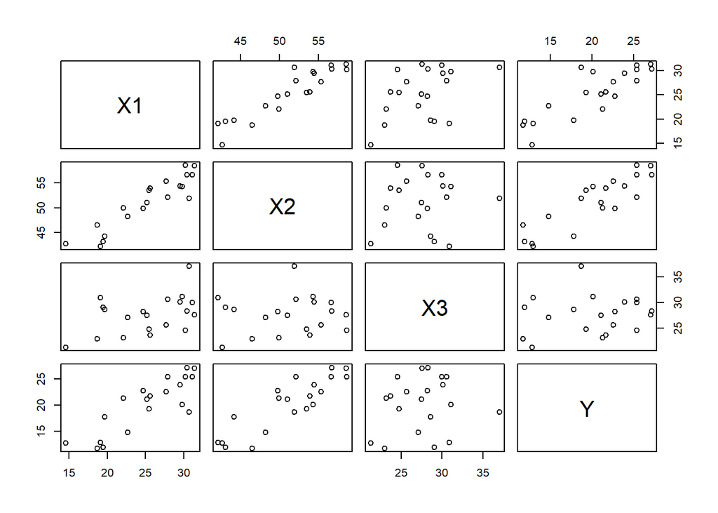

```r
# 시각화
pairs(bodyfat)
```

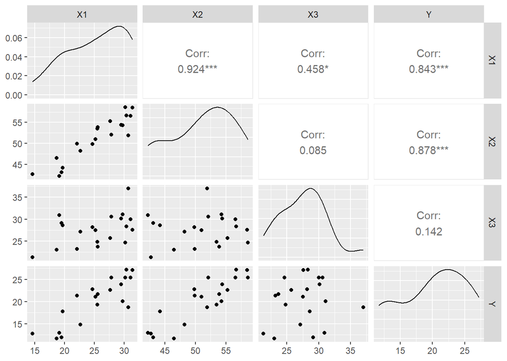

```r
library(ggplot2)
library(GGally)
ggpairs(bodyfat)
```

## 2. 선형 회귀 모델 추정

#### 2-1. 회귀 계수(bhat) 계산

```r
Y<-bodyfat$Y
X<-cbind(1,bodyfat$X1, bodyfat$X2, bodyfat$X3)
bhat<-solve(t(X)%*%X)%*%t(X)%*%Y
bhat
```

```
##            [,1]
## [1,] 117.084695
## [2,]   4.334092
## [3,]  -2.856848
## [4,]  -2.186060
```

#### 2-2. lm 함수로 회귀 모델 추정

##### 2-2-1. Y~X1

```r
lm1<-lm(Y~X1, data=bodyfat)
coef(summary(lm1))
```

```
##               Estimate Std. Error    t value     Pr(>|t|)
## (Intercept) -1.4961046  3.3192346 -0.4507378 6.575609e-01
## X1           0.8571865  0.1287808  6.6561675 3.024349e-06
```

```r
anova(lm1)
```

```
## Analysis of Variance Table
##
## Response: Y
##           Df Sum Sq Mean Sq F value    Pr(>F)
## X1         1 352.27  352.27  44.305 3.024e-06 ***
## Residuals 18 143.12    7.95
## ---
## Signif. codes:  0 '***' 0.001 '**' 0.01 '*' 0.05 '.' 0.1 ' ' 1
```

##### 2-2-2. Y~X2

```r
lm2<-lm(Y~X2, data=bodyfat)
coef(summary(lm2))
```

```
##                Estimate Std. Error   t value     Pr(>|t|)
## (Intercept) -23.6344891  5.6574137 -4.177614 5.656662e-04
## X2            0.8565466  0.1100156  7.785681 3.599996e-07
```

```r
anova(lm2)
```

```
## Analysis of Variance Table
##
## Response: Y
##           Df Sum Sq Mean Sq F value  Pr(>F)
## X2         1 381.97  381.97  60.617 3.6e-07 ***
## Residuals 18 113.42    6.30
## ---
## Signif. codes:  0 '***' 0.001 '**' 0.01 '*' 0.05 '.' 0.1 ' ' 1
```

##### 2-2-3. Y~X1+X2

```r
lm3<-lm(Y~X1+X2, data=bodyfat)
coef(summary(lm3))
```

```
##                Estimate Std. Error    t value   Pr(>|t|)
## (Intercept) -19.1742456  8.3606407 -2.2933943 0.03484327
## X1            0.2223526  0.3034389  0.7327755 0.47367898
## X2            0.6594218  0.2911873  2.2645969 0.03689872
```

```r
anova(lm3)
```

```
## Analysis of Variance Table
##
## Response: Y
##           Df Sum Sq Mean Sq F value    Pr(>F)
## X1         1 352.27  352.27 54.4661 1.075e-06 ***
## X2         1  33.17   33.17  5.1284    0.0369 *
## Residuals 17 109.95    6.47
## ---
## Signif. codes:  0 '***' 0.001 '**' 0.01 '*' 0.05 '.' 0.1 ' ' 1
```

##### 2-2-4. Y~X1+X2+X3

```r
lm4<-lm(Y~X1+X2+X3, data=bodyfat)
coef(summary(lm4))
```

```
##               Estimate Std. Error   t value  Pr(>|t|)
## (Intercept) 117.084695  99.782403  1.173400 0.2578078
## X1            4.334092   3.015511  1.437266 0.1699111
## X2           -2.856848   2.582015 -1.106441 0.2848944
## X3           -2.186060   1.595499 -1.370142 0.1895628
```

```r
anova(lm4)
```

```
## Analysis of Variance Table
##
## Response: Y
##           Df Sum Sq Mean Sq F value    Pr(>F)
## X1         1 352.27  352.27 57.2768 1.131e-06 ***
## X2         1  33.17   33.17  5.3931   0.03373 *
## X3         1  11.55   11.55  1.8773   0.18956
## Residuals 16  98.40    6.15
## ---
## Signif. codes:  0 '***' 0.001 '**' 0.01 '*' 0.05 '.' 0.1 ' ' 1
```

## 3. 선형 회귀 모델 비교

#### 3-1. lm3 vs lm4

```r
anova(lm3, lm4)
```

```
## Analysis of Variance Table
##
## Model 1: Y ~ X1 + X2
## Model 2: Y ~ X1 + X2 + X3
##   Res.Df     RSS Df Sum of Sq      F Pr(>F)
## 1     17 109.951
## 2     16  98.405  1    11.546 1.8773 0.1896
```

- p-value는 0.1896입니다. 이 값은 F 통계량에 대한 p-value를 나타냅니다. 여기서는 유의수준 0.05보다 크기 때문에 X3을 추가하여 모델이 향상되었다고 말할 수는 없습니다. 따라서 X3을 추가하여 모델을 개선하는 것은 유의하지 않다

#### 3-2. lm1 vs lm4

```r
anova(lm1, lm4)
```

```
## Analysis of Variance Table
##
## Model 1: Y ~ X1
## Model 2: Y ~ X1 + X2 + X3
##   Res.Df     RSS Df Sum of Sq      F  Pr(>F)
## 1     18 143.120
## 2     16  98.405  2    44.715 3.6352 0.04995 *
## ---
## Signif. codes:  0 '***' 0.001 '**' 0.01 '*' 0.05 '.' 0.1 ' ' 1
```

- F 통계량의 p-값이 0.04995로, 이는 유의수준 0.05보다 작기 때문에 *로 표시됩니다. 따라서 모델 2가 모델 1보다 종속 변수 Y를 설명하는 데 통계적으로 유의하게 더 적합하다는 것을 나타냅니다.
- 즉, X2와 X3을 추가한 모델 2가 X1만을 포함한 모델 1보다 Y를 설명하는 데 더 나은 모델입니다.

## 4. 합성 변수를 사용한 모델 비교

#### 4-1. X12 = X1+X2

```r
bodyfat$X12<-bodyfat$X1+bodyfat$X2

lm5<-lm(Y~X12+X3, data=bodyfat)

anova(lm5, lm4)
```

```
## Analysis of Variance Table
##
## Model 1: Y ~ X12 + X3
## Model 2: Y ~ X1 + X2 + X3
##   Res.Df     RSS Df Sum of Sq      F Pr(>F)
## 1     17 108.560
## 2     16  98.405  1    10.155 1.6511 0.2171
```

#### 4-2. GLH 검정

```r
library(gmodels)
glh.test(lm4, cm=c(0, 1, -1, 0))
```

```
##
##   Test of General Linear Hypothesis
## Call:
## glh.test(reg = lm4, cm = c(0, 1, -1, 0))
## F = 1.6511, df1 =  1, df2 = 16, p-value = 0.2171
```

- p-값이 0.2171로 유의수준인 0.05보다 크므로, X1과 X2를 개별적으로 추가하는 것이 X12를 사용하는 것보다 모델을 개선하는 데에는 통계적으로 유의미한 차이가 없다는 것을 나타냅니다.
- lm4 모델에서 X1과 X2의 회귀 계수가 동일한지 검정하는 일반 선형 가설 검정 (GLH 테스트)을 수행합니다.
- p-값이 0.05보다 크므로, 귀무가설 H0(즉,𝛽1−𝛽2 = 0)을 기각할 수 없습니다.
- 이는 X1과 X2의 회귀 계수가 유의미하게 다르지 않다는 것을 의미합니다.

## 5. 회귀 계수를 계산하는 3가지 방법

#### 5-1. 일반 선형 회귀(Ordinary Linear Regression)

- 최소제곱법(OLS)을 사용하여 회귀계수를 추정
- 절편 포함 가능
- 데이터 단위 그대로 사용
- 가장 직관적이나 다중공선성에 민감하고 변수 단위가 다르면 계수 비교 어려움

```r
lm.bodyfat <- lm(Y~X1+X2, data=bodyfat)
lm.bodyfat
```

```
##
## Call:
## lm(formula = Y ~ X1 + X2, data = bodyfat)
##
## Coefficients:
## (Intercept)           X1           X2
##    -19.1742       0.2224       0.6594
```

#### 5-2. 표준화 회귀(Standardized regression)

- Y와 X를 모두 표준화(z-score)
- 절편 제거 (0 +)
- 단위에 상관없이 변수 영향력 비교 가능
- 변수 간 영향력 비교 가능하나 절편 정보가 손실되어 실제 값 단위로 해석 불가

```r
lm(scale(Y)~0+scale(X1)+scale(X2), data=bodyfat)
```

```
##
## Call:
## lm(formula = scale(Y) ~ 0 + scale(X1) + scale(X2), data = bodyfat)
##
## Coefficients:
## scale(X1)  scale(X2)
##    0.2187     0.6760
```

#### 5-3. 상관행렬 이용 계산(Correlation Matrix Method)

- X의 상관행렬과 Y-X 상관행렬 이용
- 수학적으로 계수 산출 과정이 명확이 드러나고, 적은 변수에서 직관적이나 변수 개수가 많으면 계산이 어렵고 절편 포함 시 별도 처리가 필요

```r
# step1) X1과 X2의 상관행렬 Rxx
Rxx<-cor(cbind(bodyfat$X1, bodyfat$X2))

# step2) Y와 X1,X2의 상관행렬 Ryx
Ryx<-rbind(cor(bodyfat$Y, bodyfat$X1), cor(bodyfat$Y, bodyfat$X2))

# step3) Rxx-1*Ryx를 행렬 연산
solve(Rxx)%*%Ryx
```

```
##           [,1]
## [1,] 0.2187415
## [2,] 0.6760069
```